# Association Rule Mining

## Module 1

### Brock Tibert

### January 27, 2021

# Outline for Today

- Discuss the mechanics and delivery of the course
- Base `python` versus External Packages
- What we will cover and learn this semester
- Topic 1: Association Rules for Pattern Discovery
  - Method/Approach
  - Evaluation
  - Applications
  - Hands on lab

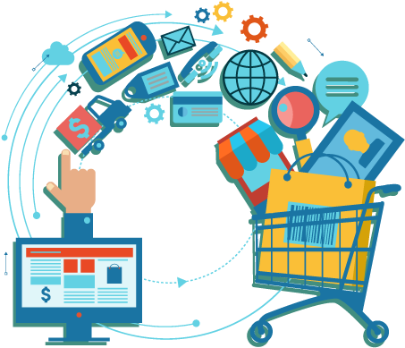

## LFA In-Class Attendance Module

- For those of us who may attend in-person, Questrom will be using a new app, and not the utility found on QTools.
- Hopefully this makes signing up for class easier all around, but this is also my first time using the tool
- As always, please don't hesitate to reach out on the forums if you run into issues

> All of our classes will be recorded and posted to the Media Gallery on QTools.

Course Delivery Overview

# Course Dellivery

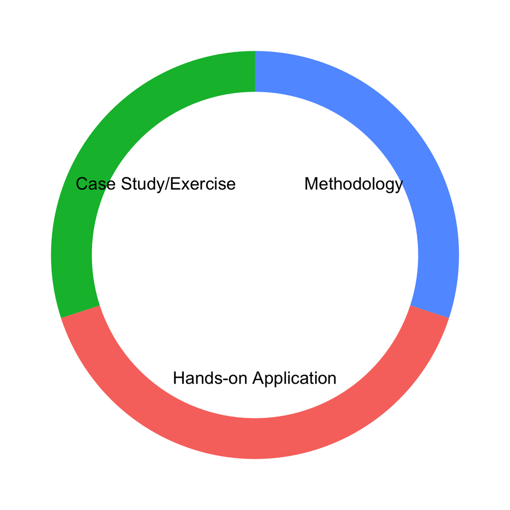

A _slightly_ different approach compared to `BA760`

- Discuss the method and the mechanics/understanding of how it works
- Explore the tools available to us in the `python` ecosystem
- Build mental models of how to include each technique into a larger analytics project, with a focus on reporting technical results to a nontechnical audience
- In-class Exercises / Case Studies / Competitions to be completed as teams
- Yes we will write code, but it's about coding up the model __AND__ interpreting/presenting the findings

# Overview

- Just like with `765`, I believe DataCamp is an important facet of this offering
  - It is important to review the DataCamp material
  - Think of this as the equivalent of assigned readings for a class, but I leave it to you whether its more helpful before or after a class meeting.

> Class preparation makes these advanced topics, especially when we are writing code, easier in the long run.

- You will leave this class with the ability to build both write code to solve analytical challenges, and discuss your findings with a variety of audiences

- It's about understanding the methods, applying them, and telling a story of the results.  Why does it matter?  Are we introducing risk/uncertainty into the business?

Moving Beyond Base `python`